# CRE Stock Valuations Estimates - Draft Methodology

- Show All Code
- Hide All Code
- View Source

Author

Sameer Shaikh

Published

April 8, 2024

Modified

June 19, 2024

# 1 Background

**Note**

This is an exploratory data file. Do not use as final output. This was done back in April 2024, as some preliminary analysis.

The purpose of this file is to clearly show how we get from Valuations Office data on rental values on all Irish commercial property stock (with some minor exceptions) to an estimate of the total size of Irish CRE. This file at the moment will NOT have full estimates of **investable** CRE yet (stripping out own-use) - I am going to work on that at a later stage (unclear if possible to do within timeline of FSC) but this is to arrive at a “best-sense” estimate.

To clarify also - this doesn’t have a valuation of the **residential** portion of commercial property stock.

# 2 Data Inputs

- Tailte Éireann Valuation Open Data
- MSCI Quarterly Commercial Property Index: Rental Value Growth Index (for cumulative changes in Rental Value to 2023Q4), by type of CRE stock (Office, Retail, Industrial, All)
- Some measure of yields of rental value - can source MSCI directly, or some other dataset.
- (*Potentially*) For getting the proportion of stock that is **not own-use:** PRSA’s Commercial Lease Register.

## 2.1 Tailte Éireann Valuations Office

Briefly - TÉ provide an API for data on all commercial and industrial property they they have valued as part of the National Revaluation Project. This is done at the Local Authority level, and has been ongoing for 2011. The dataset provides **rental valuations** of every rateable commercial and industrial property in the country, with reference to a specific valuation date within a local authority.

For a wider background on the data - please see my data summary file, `CRE-Valuations-Explore.qmd`, or the stakeholder presentation for the 2023 Revaluation Programme, [at this link](https://tailte.ie/en/valuation/revaluation/reval-23-powerpoint-briefings-to-stakeholders/reval23-presentation-september-2023.pdf).

The valuations reflect the market rental values at that valuation date, so one step will be to index up the rental valuations to the most recently available data.

Additionally - we are going to have to exclude Cork, as this is the only county that has yet to do a revaluation of it’s commercial stock to reflect current market values.

```r
head(valuations)
```

| PropertyNumber | PublicationDate | LocalAuthority | ValuationDate | Xitm | Yitm | Valuation | ValuationReport | Uses | Category | CarPark | AdditionalItems | Address1 | Address2 | Address3 | Address4 | Address5 | Eircode | County | NetFloorArea |
| --- | --- | --- | --- | --- | --- | --- | --- | --- | --- | --- | --- | --- | --- | --- | --- | --- | --- | --- | --- |
| 207 | 2023-09-22 | KERRY COUNTY COUNCIL | 2022-02-01 | 443393.0 | 566115.2 | 31500 |  | PUB, GUESTHOUSE | HOSPITALITY | 0 | NA | BALLINSKELLIGS | KERRY | NA | NA | NA | V23TP64 | KERRY | 0.00 |
| 214 | 2023-09-22 | KERRY COUNTY COUNCIL | 2022-02-01 | 443248.5 | 565966.4 | 7990 |  | -, FACTORY | INDUSTRIAL USES | 0 | NA | LOCAL NO/MAP REF: 3D | BALLINSKELLIGS | CAHERCIVEEN CO. KERRY | NA | NA | V23Y682 | KERRY | 532.81 |
| 498 | 2023-09-22 | KERRY COUNTY COUNCIL | 2022-02-01 | 444068.4 | 567068.6 | 14400 |  | -, PUB | HOSPITALITY | 0 | NA | DUNGERGAN | BALLINSKELLIGS | NA | NA | NA | V23E368 | KERRY | 0.00 |
| 515 | 2023-09-22 | KERRY COUNTY COUNCIL | 2022-02-01 | 443988.1 | 567104.3 | 15130 |  | -, FACTORY | INDUSTRIAL USES | 0 | NA | LOCAL NO/MAP REF: 9B | DUNGEAGAN | BALLINSKELLIGS | CAHERCIVEEN CO. KERRY | NA | V23XR52 | KERRY | 1164.00 |
| 763 | 2023-09-22 | KERRY COUNTY COUNCIL | 2022-02-01 | 452217.7 | 564737.6 | 11000 |  | GUEST ACCOMMODATION, - | HOSPITALITY | 0 | 11000 | LOCAL NO/MAP REF: 1AAB1 | EIGHTERCUA | BALLYBRACK | CAHERCIVEEN CO. KERRY | NA | V23WN34 | KERRY | 356.04 |
| 945 | 2023-09-22 | KERRY COUNTY COUNCIL | 2022-02-01 | 446547.0 | 579271.7 | 2880 |  | -, SHOP (OFFICES) | RETAIL (SHOPS) | 0 | NA | LOCAL NO/MAP REF: 6D | CAHERCIVEEN | CAHER | CAHERCIVEEN CO. KERRY | NA | V23X897 | KERRY | 48.00 |

## 2.2 MSCI Quarterly Property Index Data

Already widely used within MFD to aid analysis in changes in the Capital Values over time, I am going to use **rental value index** to get the cumulative growth in rents from the valuation quarter until the latest available quarterly index data.

## 2.3 Capitalisation Rates Data

We can use a variety of sources to convert rental to capital values, would involve taking private market data on capitalisation rates on segment **and** location. We want rental values as a % of **market values** of the property, not yields.

However - private market sources will use the term `investment yields` (which sound similar to rental values as a % of cost of investment [incl. borrowing costs]) but explain movements in the yields as if they are referring to cap rates (market valuations declining due to interest rates, etc.).

For now, I’m using **MSCI Equivalent Yields** data for most , without regard to regional splits **at the minute. We can come back to this**.

The choice to use *Equivalent Yields* comes from their explanation in the methodology documents for the MSCI Quarterly Index[^1]:

> Only used in the U.K. and Ireland, the discount rate that equates future income flows to the gross capital value. This is calculated on a quarterly in advance (true equivalent yield) basis. The equivalent yield discounts the current rental value in perpetuity beyond the last review date recorded for the tenancies in the subset.

# 3 Data Preparation

Some columns to add - create yearQtr columns for MSCI indexes and VO data ValuationDates

```
[[1]]
          yqtr       date   all retail office industrial
     <yearqtr>     <IDat> <num>  <num>  <num>      <num>
  1:   1994 Q4 1994-12-31 100.0  100.0  100.0      100.0
  2:   1995 Q1 1995-03-31 101.0  101.6  100.6      101.0
  3:   1995 Q2 1995-06-30 101.7  102.8  100.9      101.8
  4:   1995 Q3 1995-09-30 102.3  103.6  101.5      102.3
  5:   1995 Q4 1995-12-31 104.4  105.7  103.6      104.9
 ---
113:   2022 Q4 2022-12-31 242.3  185.4  280.3      201.5
114:   2023 Q1 2023-03-31 234.6  181.1  269.3      199.0
115:   2023 Q2 2023-06-30 227.1  179.4  257.7      196.1
116:   2023 Q3 2023-09-30 218.9  175.2  245.1      197.5
117:   2023 Q4 2023-12-31 210.5  168.7  233.3      198.0

```

[output cut: 58 more lines]

For later - to do a small bit of address cleaning (or really, concatenate the address fields into one, for fuzzy matching later to lease register).

Match your 4 categories: Office, Industrial, Retail, and “All” (generic ‘other’).

Quick check of counts:

```r
valuations[, .N, Category][order(-N)]
```

| Category | N |
| --- | --- |
| RETAIL (SHOPS) | 44453 |
| INDUSTRIAL USES | 37469 |
| OFFICE | 28984 |
| HOSPITALITY | 7632 |
| MISCELLANEOUS | 2990 |
| LEISURE | 1730 |
| RETAIL (WAREHOUSE) | 1705 |
| FUEL/DEPOT | 1658 |
| HEALTH | 708 |
| MINERALS | 440 |

[output cut: 4 more lines]

```r
valuations[, segment := fcase(
  Category %chin% c("RETAIL (SHOPS)", "RETAIL (WAREHOUSE)"), "retail",
  Category == "OFFICE", "office",
  Category %chin% c("INDUSTRIAL USES", "MINERALS"), "industrial",
  default = "all"
)]

valuations[, .N, keyby = .(segment)]
```

| segment | N |
| --- | --- |
| all | 15020 |
| industrial | 37909 |
| office | 28984 |
| retail | 46158 |

### 3.0.1 Exclusion of Certain Non-CRE property

```r
## Exclusion of certain commercial property ----------------
valuations <- valuations[ !( !(Category %chin% c("OFFICE", "RETAIL (SHOPS)", "RETAIL (WAREHOUSE)")) & grepl("generating|incinerator|tolls|terminal|airport|\\bport\\b|\\bbus\\b|\\bfuneral\\b|\\bfire\\b \\bstation\\b|\\bantenna|\\bcaravan|\\basylum", Uses, ignore.case = TRUE)),]
valuations <- valuations[!(Category == "UTILITY" & !grepl("\\bwind\\b", Uses, ignore.case = TRUE)), ]
valuations <- valuations[!(Category %chin% c("NON-LIST", "CHECK CATEGORY", "NO CATEGORY SELECTED", "MINERALS"))]
```

## 3.1 Some charts (prelim)

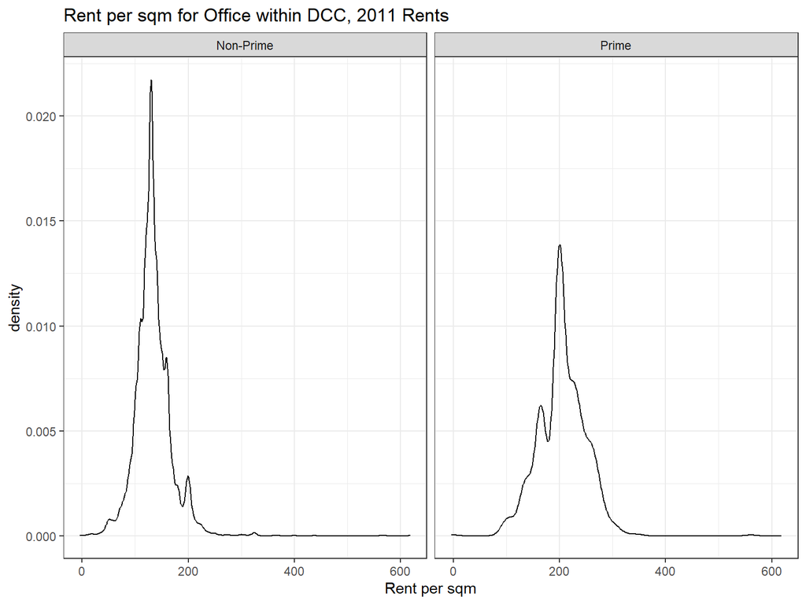

```r
valuations[Category == "OFFICE", office_gen :=
             fcase(
             grepl("4th gen|3rd gen", Uses, ignore.case = TRUE, perl = TRUE), "Prime",
             default = "Non-Prime"
             )]

ggplot2::ggplot(data = valuations[LocalAuthority == "DUBLIN CITY COUNCIL" & Category == "OFFICE" & Valuation < 100000 & NetFloorArea != 0, ], aes(x = Valuation/NetFloorArea)) + geom_density() + facet_wrap(~office_gen) + xlab("Rent per sqm") + ggtitle("Rent per sqm for Office within DCC, 2011 Rents")
```

# 4 Indexing Rental Values

## 4.1 Method 1: Segmentation without Regional Variation

For the segments you want to index up, you want to get the cumulative growth from the reference valuation quarters to the latest available quarter. I’ve coded the below to be **dynamic:** if we update the values of the index quarterly (or increase the number of segments for granularity), then the code below should still work without much further fuss. Do provide feedback on better methods, though.

```r
cols <- grep("date|yqtr", names(msci_rental), value = TRUE, invert = TRUE)

msci_rental[, paste0(cols, "_cuminc") := lapply(.SD, function(segment) {
 segment[yqtr == data.table::last(yqtr)]/segment
}), .SDcols = cols]

cols_cuminc <- paste0(cols, "_cuminc")

msci_rental_cuminc <- msci_rental[, !..cols][, !c("date")]

msci_rental_cuminc_multiplier <- melt(msci_rental_cuminc, id.vars = c("yqtr"), variable.name = "segment", value.name = "multiplier")

msci_rental_cuminc_multiplier[, segment := gsub("_cuminc", "", segment)]
```

So to show the output below: Here’s the scalar multipliers that will be used to uprate the values. For a value that was last valued in 1994 Q4 in the “All” segment within the Valuations dataset, you would apply a 2.11x multiplier to get the cumulative increase in the rental value to today.

```r
msci_rental_cuminc_multiplier
```

| yqtr | segment | multiplier |
| --- | --- | --- |
| 1994 Q4 | all | 2.1100000 |
| 1995 Q1 | all | 2.0974155 |
| 1995 Q2 | all | 2.0767717 |
| 1995 Q3 | all | 2.0625611 |
| 1995 Q4 | all | 2.0386473 |
| 1996 Q1 | all | 2.0288462 |
| 1996 Q2 | all | 2.0057034 |
| 1996 Q3 | all | 1.9793621 |
| 1996 Q4 | all | 1.9164396 |
| 1997 Q1 | all | 1.8856122 |

[output cut: 458 more lines]

```r
valuations <- msci_rental_cuminc_multiplier[valuations, on = c("yqtr" = "val_qtr", "segment")][, indexed_vals := Valuation*multiplier]

setcolorder(valuations, c("yqtr", "LocalAuthority", "segment", "Valuation", "multiplier", "indexed_vals"))
```

## 4.2 Summary Statistics on Indexation result

Summary over Valuation LAs

```r
quick_summary <- valuations[, .(`No. of Local Authorities` = uniqueN(LocalAuthority),
               Properties = .N,
               Rents = sum(Valuation),
               IndexedRents = sum(indexed_vals),
               Uplift = scales::label_percent(accuracy = 0.01)(sum(indexed_vals)/sum(Valuation)-1)), keyby = .(yqtr)]

quick_summary[, `:=` (`Rent %` = scales::label_percent()(Rents/sum(Rents)), `Indexed Rents %` = scales::label_percent()(IndexedRents/sum(IndexedRents)), Rents = scales::label_comma()(Rents), IndexedRents = scales::label_comma()(IndexedRents))][,]
```

| yqtr | No. of Local Authorities | Properties | Rents | IndexedRents | Uplift | Rent % | Indexed Rents % |
| --- | --- | --- | --- | --- | --- | --- | --- |
| 2011 Q2 | 1 | 19660 | 1,233,537,015 | 1,823,611,972 | 47.84% | 22.75% | 27.0% |
| 2011 Q4 | 1 | 3765 | 99,624,703 | 140,274,807 | 40.80% | 1.84% | 2.1% |
| 2012 Q1 | 1 | 6500 | 176,310,458 | 256,782,083 | 45.64% | 3.25% | 3.8% |
| 2015 Q4 | 11 | 30761 | 1,156,241,240 | 1,525,515,724 | 31.94% | 21.32% | 22.6% |
| 2017 Q3 | 8 | 33506 | 1,398,957,600 | 1,608,278,244 | 14.96% | 25.80% | 23.8% |
| 2022 Q1 | 7 | 32304 | 1,358,236,494 | 1,410,077,362 | 3.82% | 25.05% | 20.8% |

By segment

```r
valuations[, .(Properties = .N, Rents = sum(Valuation), IndexedRents = sum(indexed_vals), Uplift = scales::label_percent(accuracy = 0.01)(sum(indexed_vals)/sum(Valuation)-1) ), keyby = .(segment)][, `:=` (Rents = label_comma()(Rents), IndexedRents = label_comma()(IndexedRents))][,]
```

| segment | Properties | Rents | IndexedRents | Uplift |
| --- | --- | --- | --- | --- |
| all | 13957 | 1,271,103,556 | 1,465,968,422 | 15.33% |
| industrial | 37397 | 1,600,191,495 | 2,287,260,536 | 42.94% |
| office | 28984 | 1,150,794,403 | 1,630,065,106 | 41.65% |
| retail | 46158 | 1,400,818,055 | 1,381,246,128 | -1.40% |

## 4.3 Method 2: Segmentation With Regional Variation

Implemented Regional Splits so far:

- All (Other): Dublin, Non-Dublin
- Industrial: Dublin, Non-Dublin
- Office: Non-Dublin, Central Dublin (DCC), Rest of Dublin (DLRCC, SDCC, Fingal).
- Retail (Shops Only): Grafton Street / Henry&Mary Street, Other City Centre, Non-Dublin
  - Note: Would really like Shopping Centre as a separate split, but can’t do here. Also, I do not use Retail Warehouse.
  - Retail Provincial is also ignored - the price decline is stark
- Retail Warehouse is also split out from Retail.

**Important**

I would like to implement further variation by having something **beyond** Non-Dublin, but I need some other data source - I don’t think there’s any other data source available.

Demonstrating variation in decline, by showing cumulative changes by these Subsegments since 2011 Q1 to the latest available quarter.

| Segment1 | Segment2 | Reference Valuation Quarter | Indexed Value, Latest Quarter | % Cumulative Change since Reference Quarter |
| --- | --- | --- | --- | --- |
| All | NA | 2011 Q1 | 153.04437 | 37.87 |
| Dublin | All | 2011 Q1 | 151.16914 | 41.88 |
| Dublin | Industrial | 2011 Q1 | 98.27656 | 49.89 |
| Industrial | NA | 2011 Q1 | 97.08693 | 48.83 |
| Office | NA | 2011 Q1 | 150.19196 | 64.70 |
| Retail | NA | 2011 Q1 | 192.79198 | -12.41 |
| Office - Central Dublin | NA | 2011 Q1 | 155.77391 | 71.37 |
| Office - Rest of Dublin | NA | 2011 Q1 | 134.37419 | 37.60 |
| Retail - Grafton Street | NA | 2011 Q1 | 288.65956 | -15.32 |
| Retail - Henry/MaryStreet | NA | 2011 Q1 | 201.74850 | -29.42 |

[output cut: 4 more lines]

Preparing table

```r
msci_rental_seg <- msci_rental_seg[!(Segment1 %chin% c("Retail - Shopping Centre", "Retail - Provincial"))]
```

```r
msci_rental_seg[, `:=` (Segment_Full = fifelse(!is.na(Segment2), paste(Segment1, Segment2, sep = " - "),
                                      Segment1),
                    Location = fcase(
                      grepl("^All Segment|^Global Property Classification sectors", Segmentation), "NATIONAL",
                      grepl("^Global Cities|^Sector by Region", Segmentation) & Segment1 != "RETAIL (WAREHOUSE)", "DUBLIN",
                      Segment1 == "Retail Warehouse", "NATIONAL",
                      default = NA)
                   )]

msci_rental_seg[, .N, .(Location, Segment1, Segment2)]
```

| Location | Segment1 | Segment2 | N |
| --- | --- | --- | --- |
| NATIONAL | All | NA | 56 |
| DUBLIN | Dublin | All | 56 |
| DUBLIN | Dublin | Industrial | 56 |
| NATIONAL | Industrial | NA | 56 |
| NATIONAL | Office | NA | 56 |
| NATIONAL | Retail | NA | 56 |
| DUBLIN | Office - Central Dublin | NA | 56 |
| DUBLIN | Office - Rest of Dublin | NA | 56 |
| DUBLIN | Retail - Grafton Street | NA | 56 |
| DUBLIN | Retail - Henry/MaryStreet | NA | 56 |

[output cut: 2 more lines]

```r
# msci_rental[, .(Segmentation, Segment1, Segment2, Segment_Full)]

# ggplot(data = msci_rental, aes(x = Period, y = Value, colour = Segment_Full)) + geom_line(linewidth = 0.7)
```

Have the location down - Now, to Subsegments

```r
msci_rental_seg[, Subsegment := fifelse(Location == "NATIONAL", Segment1,
                                         fifelse(Segment1 == "Dublin", Segment2, Segment1)
                                         )]

msci_rental_seg[, .N, .(Location, Subsegment, Segment1, Segment2)]
```

| Location | Subsegment | Segment1 | Segment2 | N |
| --- | --- | --- | --- | --- |
| NATIONAL | All | All | NA | 56 |
| DUBLIN | All | Dublin | All | 56 |
| DUBLIN | Industrial | Dublin | Industrial | 56 |
| NATIONAL | Industrial | Industrial | NA | 56 |
| NATIONAL | Office | Office | NA | 56 |
| NATIONAL | Retail | Retail | NA | 56 |
| DUBLIN | Office - Central Dublin | Office - Central Dublin | NA | 56 |
| DUBLIN | Office - Rest of Dublin | Office - Rest of Dublin | NA | 56 |
| DUBLIN | Retail - Grafton Street | Retail - Grafton Street | NA | 56 |
| DUBLIN | Retail - Henry/MaryStreet | Retail - Henry/MaryStreet | NA | 56 |

[output cut: 2 more lines]

Great! Now to create your cumulative growth to latest period:

```r
msci_rental_seg[, regional_multiplier := Value[Period == "2023-12-31"]/Value, by = .(Location, Subsegment)]

msci_rental_seg <- msci_rental_seg[, .(yqtr, Location, Subsegment, regional_multiplier)]

msci_rental_seg[Subsegment == "Retail Warehouse", Location := "NATIONAL"]
```

```r
valuations[, Address := do.call(paste, c(lapply(.SD, function(x) {replace(x, is.na(x), "")}), sep=" ")), .SDcols = Address1:Address5]
```

Here is the breakdown by Subsegments:

Breakdown by Subsegments

| Location | Subsegment | segment | N | Floor Area |
| --- | --- | --- | --- | --- |
| NATIONAL | All | all | 11072 | 7659740.01 |
| NATIONAL | Industrial | industrial | 27645 | 34405926.24 |
| NATIONAL | Retail | retail | 37333 | 7085623.94 |
| NATIONAL | Office | office | 16501 | 2609292.78 |
| NATIONAL | Retail Warehouse | retail | 1705 | 3331130.40 |
| DUBLIN | All | all | 2885 | 1445825.44 |
| DUBLIN | Industrial | industrial | 9752 | 11932694.92 |
| DUBLIN | Office - Rest of Dublin | office | 4885 | 1559820.76 |
| DUBLIN | Office - Central Dublin | office | 7598 | 2976920.19 |
| DUBLIN | Retail - Other City Centre | retail | 6907 | 1037033.46 |
| DUBLIN | Retail - Henry/MaryStreet | retail | 111 | 153176.38 |
| DUBLIN | Retail - Grafton Street | retail | 102 | 68479.39 |

```r
msci_rental_seg[valuations, on = c("yqtr", "Location", "Subsegment")][, mean(regional_multiplier-multiplier), by = .(yqtr, Location, Subsegment)]
```

| yqtr | Location | Subsegment | V1 |
| --- | --- | --- | --- |
| 2022 Q1 | NATIONAL | All | -0.00015087420 |
| 2022 Q1 | NATIONAL | Industrial | 0.00008772645 |
| 2022 Q1 | NATIONAL | Retail | -0.00009693099 |
| 2022 Q1 | NATIONAL | Office | -0.00012864778 |
| 2022 Q1 | NATIONAL | Retail Warehouse | 0.00812524423 |
| 2015 Q4 | NATIONAL | Industrial | -0.00082530955 |
| 2015 Q4 | NATIONAL | Office | -0.00030866965 |
| 2015 Q4 | NATIONAL | All | 0.00022544066 |
| 2015 Q4 | NATIONAL | Retail | -0.00046974132 |
| 2015 Q4 | NATIONAL | Retail Warehouse | 0.18547730170 |

[output cut: 31 more lines]

```r
valuations_segmented <- msci_rental_seg[valuations, on = c("yqtr", "Location", "Subsegment")][, indexed_vals2 := Valuation*regional_multiplier]

valuations_segmented[, .(Properties = .N, Rents = sum(Valuation), IndexedRents = label_comma()(sum(indexed_vals2)), Uplift = scales::label_percent(accuracy = 0.01)(sum(indexed_vals2)/sum(Valuation)-1) ), keyby = .(Subsegment)][, `:=` (Rents = label_comma()(Rents))][,]
```

| Subsegment | Properties | Rents | IndexedRents | Uplift |
| --- | --- | --- | --- | --- |
| All | 13957 | 1,271,103,556 | 1,475,740,411 | 16.10% |
| Industrial | 37397 | 1,600,191,495 | 2,290,713,281 | 43.15% |
| Office | 16501 | 225,244,683 | 261,484,535 | 16.09% |
| Office - Central Dublin | 7598 | 585,101,470 | 1,060,472,105 | 81.25% |
| Office - Rest of Dublin | 4885 | 340,448,250 | 355,161,712 | 4.32% |
| Retail | 37333 | 962,660,044 | 965,156,710 | 0.26% |
| Retail - Grafton Street | 102 | 25,929,485 | 23,367,856 | -9.88% |
| Retail - Henry/MaryStreet | 111 | 33,963,430 | 24,782,180 | -27.03% |
| Retail - Other City Centre | 6907 | 220,690,327 | 200,730,723 | -9.04% |
| Retail Warehouse | 1705 | 157,574,769 | 179,112,772 | 13.67% |

```r
valuations[, .SD[which.max(indexed_vals), .(PropertyNumber, Category, County, Uses, Address1, Valuation, indexed_vals, CarPark, AdditionalItems, NetFloorArea)], by = .(Category)]
```

| Category | PropertyNumber | Category | County | Uses | Address1 | Valuation | indexed_vals | CarPark | AdditionalItems | NetFloorArea |
| --- | --- | --- | --- | --- | --- | --- | --- | --- | --- | --- |
| HOSPITALITY | 5019729 | HOSPITALITY | LONGFORD | HOLIDAY COMPLEX, - | Centre Parks Ireland Ltd | 5200000 | 5966286 | 0 | 5200000.00 | 0.00 |
| INDUSTRIAL USES | 1739653 | INDUSTRIAL USES | KILDARE | FACTORY (COMPUTER) | INTEL IRELAND LTD. | 73500000 | 116711538 | 0 | NA | 1.00 |
| RETAIL (SHOPS) | 5008119 | RETAIL (SHOPS) | KILDARE | -, SHOP | Unit 54-86 Kildare Village | 7662000 | 7929607 | 0 | NA | 19505.87 |
| FUEL/DEPOT | 292850 | FUEL/DEPOT | DUBLIN | AVIATION FUEL DEPOT, - | Joint Storage Facility | 2300000 | 2395360 | 0 | 2300000.00 | 1321.95 |
| OFFICE | 786926 | OFFICE | DUBLIN | OFFICE (2ND GENERATION), OFFICE (3RD GENERATION) | Merrion Road | 10296000 | 17950884 | 647 | NA | 45904.50 |
| LEISURE | 771429 | LEISURE | DUBLIN | STADIUM (GAA), CONFERENCE CENTRE | 25AB JONES ROAD | 4000000 | 5820690 | 0 | NA | 1.00 |
| MISCELLANEOUS | 5018450 | MISCELLANEOUS | DUBLIN | CAR PARK (SURFACE), CAR PARK (MULTISTOREY) | PROPERTY DEPARTMENT | 27249000 | 28378771 | 0 | 27249000.00 | 0.00 |
| HEALTH | 501257 | HEALTH | DUBLIN | -, HOSPITAL | Rock Road | 6307000 | 6422669 | 0 | NA | 1.00 |
| RETAIL (WAREHOUSE) | 2201629 | RETAIL (WAREHOUSE) | DUBLIN | -, DIY SUPERSTORE | BALLYMUN ROAD | 4400000 | 4177403 | 0 | 22999.09 | 38276.86 |
| UTILITY | 5019080 | UTILITY | MAYO | -, WIND FARM | Oweninny Wind Farm | 11293000 | 11500111 | 0 | NA | 1.00 |

# 5 Deriving Capital Values through Yield Rates

## 5.1 Crude ‘all CRE yield’ estimate

Crude estimate of 6% from Ferg’s email showing agg. CRE yield from FSR - not something I would use. It’s just the most easy thing to do, but our output is going to be widely sensitive to that one specific parameter. I am not comfortable with that **at all**.

```r
valuations[, .(Rent = scales::label_comma()(sum(indexed_vals)), `Implied Capital Values` = label_comma()(sum(indexed_vals/.06)))] |> kable()
```

| Rent | Implied Capital Values |
| --- | --- |
| 6,764,540,192 | 112,742,336,527 |

## 5.2 Segment based estimates

This one just involves:

- Collecting Private Market data on **capitalisation rates / appropriate yield** measure
- Using it to convert rentals to market values
- Todo: extend to regional yields.
  - Split based on prime and non-prime.

```r
yield_estimates <- melt(msci_equiv_yields[yqtr == data.table::last(yqtr), !c("date")], id.vars = "yqtr", variable.name = "segment", value.name = "yield")[, !c("yqtr")]

yield_estimates |> kable(caption = "Yields used for Segment based Estimate")
```

Yields used for Segment based Estimate

| segment | yield |
| --- | --- |
| all | 6.61509 |
| retail | 6.91725 |
| office | 6.72961 |
| industrial | 5.71936 |

```r
valuations <- yield_estimates[valuations, on = "segment"][, capital_value := indexed_vals*(100/yield)]

setcolorder(valuations, c("yqtr", "LocalAuthority", "segment", "Valuation", "multiplier", "indexed_vals", "yield", "capital_value"))
```

To show what we have so far:

```r
valuations[, c("yqtr", "LocalAuthority", "segment", "Valuation", "multiplier", "indexed_vals", "yield", "capital_value")]
```

| yqtr | LocalAuthority | segment | Valuation | multiplier | indexed_vals | yield | capital_value |
| --- | --- | --- | --- | --- | --- | --- | --- |
| 2022 Q1 | KERRY COUNTY COUNCIL | all | 31500.00 | 1.0183398 | 32077.70270 | 6.61509 | 484917.1017 |
| 2022 Q1 | KERRY COUNTY COUNCIL | industrial | 7990.00 | 1.1495625 | 9185.00398 | 5.71936 | 160594.9613 |
| 2022 Q1 | KERRY COUNTY COUNCIL | all | 14400.00 | 1.0183398 | 14664.09266 | 6.61509 | 221676.3893 |
| 2022 Q1 | KERRY COUNTY COUNCIL | industrial | 15130.00 | 1.1495625 | 17392.87987 | 5.71936 | 304105.3522 |
| 2022 Q1 | KERRY COUNTY COUNCIL | all | 11000.00 | 1.0183398 | 11201.73745 | 6.61509 | 169336.1308 |
| 2022 Q1 | KERRY COUNTY COUNCIL | retail | 2880.00 | 1.0223971 | 2944.50363 | 6.91725 | 42567.5468 |
| 2022 Q1 | KERRY COUNTY COUNCIL | industrial | 4520.00 | 1.1495625 | 5196.02228 | 5.71936 | 90849.7153 |
| 2022 Q1 | KERRY COUNTY COUNCIL | industrial | 10220.00 | 1.1495625 | 11748.52824 | 5.71936 | 205416.8341 |
| 2022 Q1 | KERRY COUNTY COUNCIL | all | 17500.00 | 1.0183398 | 17820.94595 | 6.61509 | 269398.3898 |
| 2022 Q1 | KERRY COUNTY COUNCIL | retail | 5280.00 | 1.0223971 | 5398.25666 | 6.91725 | 78040.5025 |

[output cut: 9990 more lines]

```r
valuations[, .(Rent = scales::label_comma()(sum(indexed_vals)), CapitalValue = label_comma()(sum(capital_value)))]
```

| Rent | CapitalValue |
| --- | --- |
| 6,764,540,192 | 106,342,942,984 |

## 5.3 Subsegmented Estimates

Table of Yields used for Subsegment Estimates

| Location | Subsegment | yield | src | notes |
| --- | --- | --- | --- | --- |
| NATIONAL | All | 6.62 | MSCI | CBRE have no all figure |
| DUBLIN | All | 6.52 | MSCI | CBRE have no all figure |
| NATIONAL | Industrial | 5.72 | MSCI | CBRE have no National figure |
| DUBLIN | Industrial | 4.75 | CBRE | Prime Dublin |
| NATIONAL | Office | 6.73 | MSCI | CBRE have no National figure |
| NATIONAL | Retail | 6.92 | MSCI | CBRE have no National figure |
| DUBLIN | Retail - Rest of Dublin | 6.75 | CBRE | Secondary High Street |
| DUBLIN | Office - Central Dublin | 5.00 | CBRE | Prime CBD Dublin |
| DUBLIN | Office - Rest of Dublin | 9.00 | CBRE | Suburban Dublin |
| DUBLIN | Retail - Grafton Street | 5.25 | CBRE | Prime Dublin |
| DUBLIN | Retail - Henry/MaryStreet | 5.25 | CBRE | Prime Dublin |
| DUBLIN | Retail - Other City Centre | 6.75 | CBRE | Secondary High Street |
| NATIONAL | Retail Warehouse | 6.50 | CBRE | Prime |
| DUBLIN | Retail Warehouse | 6.50 | CBRE | Prime |

```r
yields_segmented <- yields_segmented[, .(Location, Subsegment, yield)]
yields_segmented
```

| Location | Subsegment | yield |
| --- | --- | --- |
| NATIONAL | All | 6.62 |
| DUBLIN | All | 6.52 |
| NATIONAL | Industrial | 5.72 |
| DUBLIN | Industrial | 4.75 |
| NATIONAL | Office | 6.73 |
| NATIONAL | Retail | 6.92 |
| DUBLIN | Retail - Rest of Dublin | 6.75 |
| DUBLIN | Office - Central Dublin | 5.00 |
| DUBLIN | Office - Rest of Dublin | 9.00 |
| DUBLIN | Retail - Grafton Street | 5.25 |

[output cut: 4 more lines]

```r
valuations_segmented <- yields_segmented[valuations_segmented, on = c("Location", "Subsegment")][, `:=` (capital_value1 = indexed_vals*(100/yield), capital_value2 =  indexed_vals2*(100/yield))]

valuations_segmented[, .(Rent = scales::label_comma()(sum(indexed_vals2)), CapitalValue = label_comma()(sum(capital_value1)), CapitalValue2 = label_comma()(sum(capital_value2)))]
```

| Rent | CapitalValue | CapitalValue2 |
| --- | --- | --- |
| 6,836,722,286 | 114,608,147,290 | 115,872,045,122 |

Some summary statistics, split by Dublin/Non-Dublin, and Sub-segment

Summary Statistics for Properties, split by Non-Dublin/Dublin, and Subsegments

| Location | Subsegment | Properties | Net Floor Area | Indexed Rents | Yield | Capital Value | Avg. CV per m^2 | % of Total Capital Value |
| --- | --- | --- | --- | --- | --- | --- | --- | --- |
| DUBLIN | Industrial | 9752 | 11,932,695 | 1,054,743,491 | 4.75 | 22,205,126,119 | 1,861 | 23.76% |
| NATIONAL | Industrial | 27645 | 34,405,926 | 1,235,969,791 | 5.72 | 21,607,863,471 | 628 | 23.12% |
| NATIONAL | Office | 16501 | 2,609,293 | 261,484,535 | 6.73 | 3,885,357,138 | 1,489 | 4.16% |
| DUBLIN | Office - Central Dublin | 7598 | 2,976,920 | 1,060,472,105 | 5.00 | 21,209,442,103 | 7,125 | 22.70% |
| DUBLIN | Office - Rest of Dublin | 4885 | 1,559,821 | 355,161,712 | 9.00 | 3,946,241,247 | 2,530 | 4.22% |
| NATIONAL | Retail | 37333 | 7,085,624 | 965,156,710 | 6.92 | 13,947,351,294 | 1,968 | 14.93% |
| DUBLIN | Retail - Grafton Street | 102 | 68,479 | 23,367,856 | 5.25 | 445,102,025 | 6,500 | 0.48% |
| DUBLIN | Retail - Henry/MaryStreet | 111 | 153,176 | 24,782,180 | 5.25 | 472,041,515 | 3,082 | 0.51% |
| DUBLIN | Retail - Other City Centre | 6907 | 1,037,033 | 200,730,723 | 6.75 | 2,973,788,487 | 2,868 | 3.18% |
| NATIONAL | Retail Warehouse | 1705 | 3,331,130 | 179,112,772 | 6.50 | 2,755,581,115 | 827 | 2.95% |

Summary Statistics, Aggregated

| Location | Segment | Properties | Net Floor Area | Indexed Rents | Yield | Capital Value | Avg. CV per m^2 | % of Total Capital Value | % of Total Rental Value (Indexed) |
| --- | --- | --- | --- | --- | --- | --- | --- | --- | --- |
| DUBLIN | all | 2885 | 1,445,825 | 569,741,017 | 6.52 | 8,738,359,154 | 6,044 | 7.5% | 8.3% |
| NATIONAL | all | 11072 | 7,659,740 | 905,999,394 | 6.62 | 13,685,791,452 | 1,787 | 11.8% | 13.3% |
| DUBLIN | industrial | 9752 | 11,932,695 | 1,054,743,491 | 4.75 | 22,205,126,119 | 1,861 | 19.2% | 15.4% |
| NATIONAL | industrial | 27645 | 34,405,926 | 1,235,969,791 | 5.72 | 21,607,863,471 | 628 | 18.6% | 18.1% |
| DUBLIN | office | 12483 | 4,536,741 | 1,415,633,817 | 6.57 | 25,155,683,350 | 5,545 | 21.7% | 20.7% |
| NATIONAL | office | 16501 | 2,609,293 | 261,484,535 | 6.73 | 3,885,357,138 | 1,489 | 3.4% | 3.8% |
| DUBLIN | retail | 7120 | 1,258,689 | 248,880,759 | 6.71 | 3,890,932,028 | 3,091 | 3.4% | 3.6% |
| NATIONAL | retail | 39038 | 10,416,754 | 1,144,269,482 | 6.90 | 16,702,932,409 | 1,603 | 14.4% | 16.7% |

```r
valuations_segmented[Category == "OFFICE" & County == "DUBLIN", .(Properties = .N, `Net Floor Area` = sum(NetFloorArea), `Indexed Rents` = sum(indexed_vals2), `Capital Value` = sum(capital_value2), Yield = round(mean(yield), 2)), keyby = .(Location, office_gen)][, .(Location, `Office Gen` = office_gen, Properties, `Net Floor Area` = label_comma()(`Net Floor Area`), `Net Floor %` = round((100*`Net Floor Area`/sum(`Net Floor Area`)), 1), `Indexed Rents` = label_comma()(`Indexed Rents`), Yield, `Capital Value` = label_comma()(`Capital Value`), `Avg. CV per m^2` = label_comma()(`Capital Value`/`Net Floor Area`), `% of Total Capital Value` = scales::label_percent(accuracy = 0.1)(`Capital Value`/sum(`Capital Value`)),  `% of Total Rental Value (Indexed)` = scales::label_percent(accuracy = 0.1)(`Indexed Rents`/sum(`Indexed Rents`)))] |> kable()
```

| Location | Office Gen | Properties | Net Floor Area | Net Floor % | Indexed Rents | Yield | Capital Value | Avg. CV per m^2 | % of Total Capital Value | % of Total Rental Value (Indexed) |
| --- | --- | --- | --- | --- | --- | --- | --- | --- | --- | --- |
| DUBLIN | Non-Prime | 9887 | 2,158,366 | 47.6 | 493,301,756 | 6.56 | 8,729,551,256 | 4,045 | 34.7% | 34.8% |
| DUBLIN | Prime | 2596 | 2,378,375 | 52.4 | 922,332,061 | 6.60 | 16,426,132,094 | 6,906 | 65.3% | 65.2% |

**Important**

Beyond the purpose of this exercise being the calculation of total (and down the line, investable) CRE stock, if we want to update the FSN on Commercial Property, I think we should take advantage of the data that VO provide - we have their valuation of rent per m<sup>2</sup>, and a further well defined “Use” field (4th generation Office = Prime Office, etc.) we could take that and replace it with market reported values, etc. There is a **LOT here.**

## Footnotes

[^1]: Available at the following link - p. 51 with definitions for all other yields.